# Changepoint Analysis

To illustrate changepoint analysis, we fit a linear-linear changepoint model.

To reproduce the results, it is necessary to prepare the data set, plot base, and training and test data sets, as outlined in the “Data Preparation” section.

## Preparation

### Loading Required Packages and Data

Load the necessary packages, data sets, and other supporting files. Each element serves a specific purpose:

- **`tidyverse`**: For data manipulation and visualisation.
- **`segmented`**: To fit the changepoint model.
- **`lme4`**: Fitting a changepoint model in `segmented` requires a lme-object created using `lme4`.
- **`caret`**: To compute model performance indices.
- **`plot_base`**: A pre-configured ggplot object for visualisation.
- **Training and Test Data sets**: Required for cross-validation.

```r
# Load necessary packages
library(tidyverse)
library(segmented)
library(lme4)
library(caret)

# Load the data set
load("data/wido.rdata")

# Load the pre-configured plot base
plot_base <- readRDS("objects/plot_base.rds")

# Load training and test datasets for cross-validation
training_datasets <- readRDS("objects/training_datasets.rds")
test_datasets <- readRDS("objects/test_datasets.rds")
```

## Analysis

### Fitting the Model

Fitting a changepoint model in `segmented` requires a lme-object created using `lme4`. Create a lme-object of the model, without the changepoint. Use this lme-object to fit the changepoint model. The comments in the code below indicate what should be filled in. Instead of “pdDiag” (= correlations between random effects are constrained to be 0), “pdSymm” (= random effects and their correlations are unconstrained), and “pdBlocked” (= specify which random effects can be correlated, and which correlations are constrained to be 0) are also possible. A starting value for the changepoint needs to be specified, but using bootstrap resampling mitigates sensitivity to starting values.

```r
# Create a linear mixed-effects model object
lme_object <- lme(lifesatisfaction ~ mnths,
                  random = ~ mnths | id,
                  data = wido)

# Fit the changepoint model
cp <- segmented.lme(
  lme_object,  # The linear mixed-effects model object
  ~ mnths,     # A one-sided formula indicating the variable with a changepoint
  random =     # A list of the random effects
    list(id = pdDiag( ~ 1 + mnths + U + G0)), # U = the difference-in-slopes parameter; G0 = the changepoint
  # Note that instead of "pdDiag" above, "pdBlocked" and "pdSymm" are also possible
  psi = 0,     # Provide a starting value for the changepoint
  control = seg.control( # Use bootstrap to mitigate potential sensitivity to starting values
    display = F,
    n.boot = 100,
    seed = 123
  )
)

# Display the summary of the model
summary(cp)
```

```
Segmented mixed-effects model fit by REML
       AIC      BIC    logLik
  5409.571 5461.311 -2695.785
 Bootstrap restarting on 100 samples;  5 different solution(s)

Random effects:
 Formula: ~1 + mnths + U + G0 | id
 Structure: Diagonal
        (Intercept)       mnths            U       G0  Residual
StdDev:   0.8028599 0.005873525 0.0003828891 1.592956 0.6456952

Fixed effects:
                 Value Std.Error   DF t-value p-value
(Intercept)  4.680470 0.0620050 2111   75.48       0
-- leftS:
mnths       -0.007652 0.0006958 2111  -11.00       0
-- diffS:
U            0.015487 0.0011710 2111   13.23
-- break:
G0           5.368898 4.6777896 2111
 psi.link = identity

Standardized Within-Group Residuals:
        Min          Q1         Med          Q3         Max
-5.39537983 -0.49421689  0.06929748  0.57182047  3.49614881

Number of Observations: 2322
Number of Groups: 208
```

```r
# Display the slope estimates
slope(cp)
```

```
                   Est.       St.Err    t value     0.95.low      0.95.up
leftSlope  -0.007651572 0.0006958491 -10.996022 -0.009015412 -0.006287733
rightSlope  0.007835602 0.0010132926   7.732813  0.005849585  0.009821619
```

```r
# Compute confidence intervals for the model parameters
intervals(cp$lme.fit, which = "all")
```

```
Approximate 95% confidence intervals

 Fixed effects:
                   lower         est.        upper
(Intercept)  4.568734113  4.690331382  4.811928651
mnths       -0.009651489 -0.008286868 -0.006922246
U            0.013879689  0.016176031  0.018472374
G0          -3.804660960  5.368897948 14.542456856

 Random Effects:
  Level: id
                       lower         est.        upper
sd((Intercept)) 7.229097e-01 0.8028599098  0.891652219
sd(mnths)       4.958933e-03 0.0058735248  0.006956798
sd(U)           1.988277e-07 0.0003828891  0.737342242
sd(G0)          5.594838e-02 1.5929562719 45.354478502

 Within-group standard error:
    lower      est.     upper
0.6253740 0.6456952 0.6666767
```

## Visualisation

### Bootstrapping Confidence Intervals

Use bootstrapping to estimate the confidence intervals for the predicted values of the model. This provides a robust measure of uncertainty. Create custom functions to perform the bootstrap resampling.

```r
# For reproducibility
set.seed(123)

# Create a custom function to fit the model and generate predictions based on the estimated fixed effects
predict_fun <- function(data, mnths_vals) {

  # Create a linear mixed-effects model object
  lme_object <- lme(fixed = lifesatisfaction ~ mnths, random = ~mnths | id, data = data)

  # Apply the segmented mixed-effects model
  cp_model <- segmented.lme(
    obj = lme_object,
    seg.Z = ~mnths,
    random = list(id = pdDiag(~1 + mnths + U + G0)),
    psi = 0,
    control = seg.control(display = F, n.boot = 0),
    data = data
  )

  # Create an empty vector to store predictions for the given mnths values
  predictions <- numeric(length(mnths_vals))

  # Predict the fixed effects for each level of mnths
  for (i in 1:length(mnths_vals)) {
    mnth <- mnths_vals[i]

    # Use the breakpoint to compute predictions
    predictions[i] <- if_else(mnth < cp_model$lme.fit$coefficients$fixed[[4]],
                        (cp_model$lme.fit$coefficients$fixed[[1]] +
                           (cp_model$lme.fit$coefficients$fixed[[2]] * mnth)),
                        (cp_model$lme.fit$coefficients$fixed[[1]] +
                           ((cp_model$lme.fit$coefficients$fixed[[2]] + cp_model$lme.fit$coefficients$fixed[[3]]) * mnth)))
  }

  # Return the predicted fixed effects
  return(predictions)
}

# Manual Bootstrap Process
n_iter <- 100  # Number of bootstrap iterations

# Create an empty matrix to store the predictions
bootstrap_predictions <- matrix(NA, nrow = n_iter, ncol = length(seq(min(wido$mnths), max(wido$mnths), by = 1)))

# Define a sequence of mnths values (the levels for which predictions are to be made)
mnths_seq <- seq(min(wido$mnths), max(wido$mnths), by = 1)

# Loop over bootstrap iterations
for (i in 1:n_iter) {
  # Resample the data with replacement
  bootstrap_sample <- wido[sample(nrow(wido), replace = TRUE), ]

  # Predict fixed effects for the resampled data based on the defined mnths sequence
  bootstrap_predictions[i, ] <- predict_fun(data = bootstrap_sample, mnths_vals = mnths_seq)
}

# The bootstrap_predictions matrix now contains the predictions for each iteration and mnths value

# Calculate 95% confidence intervals from bootstrapped predictions for each mnths level
ci95 <- apply(bootstrap_predictions, 2, quantile, probs = c(0.025, 0.975), na.rm = TRUE)

# Store the lower and upper bounds in a new data frame that matches the mnths sequence
bootci_results <- data.frame(mnths = mnths_seq, lower_bound = ci95[1, ], upper_bound = ci95[2, ])
```

### Predicting Average and Individual Trajectories

Predict both the population-level (fixed effects) and individual-level (random effects) trajectories of life satisfaction.

```r
# Predict population-level trajectories based on fixed effects
wido <- wido %>%
  mutate(lifesatisfaction_cp_f = if_else(mnths < cp$lme.fit$coefficients$fixed[[4]],
                             (cp$lme.fit$coefficients$fixed[[1]] + (cp$lme.fit$coefficients$fixed[[2]] * mnths)),
                             (cp$lme.fit$coefficients$fixed[[1]] + ((cp$lme.fit$coefficients$fixed[[2]] + cp$lme.fit$coefficients$fixed[[3]]) * mnths))))

# Obtain the individual-level predictions from the cp model object
wido$lifesatisfaction_cp_r <- fitted(cp)
```

### Selecting a Random Sample for Plotting

For better visualisation, select a random sample of individuals to display their individual trajectories.

```r
# For reproducibility
set.seed(123)

# Randomly sample 50 participants
rsample_ids <- sample(unique(wido$id), 50)

# Filter the data to include only the randomly selected participants
wido_rsample <- wido %>%
  filter(id %in% rsample_ids)
```

### Creating the Plot

Combine all elements to create the plot, which includes individual trajectories, the population trajectory, and the confidence interval of the population trajectory.

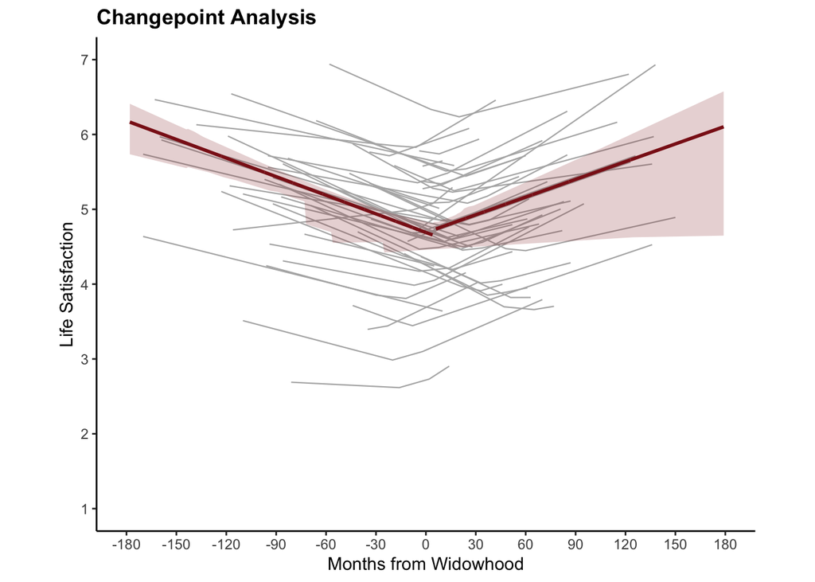

```r
# Create the plot using the pre-configured plot base
plot_base +
  geom_line(
    data = wido_rsample,
    aes(mnths, lifesatisfaction_cp_r, group = id),
    color = "grey70",
    linewidth = 0.4
  ) +
  geom_line(
    data = wido,
     aes(
      x = mnths,
      y = ifelse(mnths == round(cp$lme.fit$coefficients$fixed[[4]], 0), NA, lifesatisfaction_cp_f)
      ),
    color = "firebrick4",
    linewidth = 1
  ) +
  geom_ribbon(
    data = bootci_results,
    aes(ymin = lower_bound, ymax = upper_bound, x = mnths),
    alpha = 0.2,
    fill = "firebrick4"
  ) +
  ggtitle("Changepoint Analysis") +
  theme(plot.title = element_text(size = 13, face = "bold"))
```

## Model Performance

### Evaluating the Model

Assess the model’s performance using the Bayesian Information Criterion (BIC), R-squared (R²), Mean Absolute Error (MAE), and Root Mean Squared Error (RMSE).

```r
# Compute BIC for the fitted model
round(BIC(cp), 2)
```

```
[1] 5461.31
```

```r
# Calculate R², MAE, and RMSE for the fixed effects predictions
data.frame(
  R2_FE = round(R2(wido$lifesatisfaction_cp_f, wido$m_lifesat_per_mnth), 2),
  MAE_FE = round(MAE(wido$lifesatisfaction_cp_f, wido$m_lifesat_per_mnth), 2),
  RMSE_FE = round(RMSE(wido$lifesatisfaction_cp_f, wido$m_lifesat_per_mnth), 2)
)
```

```
  R2_FE MAE_FE RMSE_FE
1  0.17   0.35    0.48
```

```r
# Calculate R², MAE, and RMSE for the random effects predictions
data.frame(
  R2_RE = round(R2(wido$lifesatisfaction_cp_r, wido$lifesatisfaction), 2),
  MAE_RE = round(MAE(wido$lifesatisfaction_cp_r, wido$lifesatisfaction), 2),
  RSME_RE = round(RMSE(wido$lifesatisfaction_cp_r, wido$lifesatisfaction), 2)
)
```

```
  R2_RE MAE_RE RSME_RE
1   0.7   0.46    0.61
```

### Cross-Validation

To assess the replicability of the model, perform cross-validation using the training and test datasets. For each training dataset, fit the model and compute performance metrics for the associated test dataset R², MAE, and RMSE.

```r
# Initialise vectors to store performance metrics
R2_values <- c()
MAE_values <- c()
RMSE_values <- c()

# Loop over the datasets
for (i in 1:length(training_datasets)) {
  # Get the current training and test dataset
  training_data <- training_datasets[[i]]
  test_data <- test_datasets[[i]]

  # Fit the initial linear mixed model
  fit_lme <- lme(lifesatisfaction ~ mnths, random = ~mnths | id, data = training_data)

  # Apply the segmented mixed-effects model
  cp <- segmented.lme(
    fit_lme,
    ~mnths,
    random = list(id = pdDiag(~1 + mnths + U + G0)),  # Adjust as needed based on your actual random effects
    psi = 0,  # Initial breakpoint value for segmentation
    control = seg.control(display = F, n.boot = 100, seed = 123)
  )

  # Predict fixed effects from the segmented model
  test_data <- test_data %>%
    mutate(pred_cp_f = if_else(mnths < cp$lme.fit$coefficients$fixed[[4]],
                               (cp$lme.fit$coefficients$fixed[[1]] + (cp$lme.fit$coefficients$fixed[[2]]*mnths)),
                               (cp$lme.fit$coefficients$fixed[[1]] + ((cp$lme.fit$coefficients$fixed[[2]] + cp$lme.fit$coefficients$fixed[[3]])*mnths))))

  # Compute average test trajectory
  test_data <- test_data %>%
    group_by(mnths) %>%
    mutate(mean_ls = mean(lifesatisfaction, na.rm = TRUE))

  # Compute performance metrics
  R2_value <- R2(test_data$pred_cp_f, test_data$mean_ls)
  RMSE_value <- RMSE(test_data$pred_cp_f, test_data$mean_ls)
  MAE_value <- MAE(test_data$pred_cp_f, test_data$mean_ls)

  # Store the metrics
  R2_values <- c(R2_values, R2_value)
  RMSE_values <- c(RMSE_values, RMSE_value)
  MAE_values <- c(MAE_values, MAE_value)
}

# Compute average performance metrics (mean)
  average_R2 <- mean(R2_values)
  average_MAE <- mean(MAE_values)
  average_RMSE <- mean(RMSE_values)

# Compute average performance metrics (SD)
  sd_R2 <- sd(R2_values)
  sd_MAE <- sd(MAE_values)
  sd_RMSE <- sd(RMSE_values)

# Combine the mean and standard deviation into one data.frame
combined_metrics <- data.frame(
  Metric = c("R²", "MAE", "RMSE"),
  Mean = round(c(average_R2, average_MAE, average_RMSE), 2),
  SD = round(c(sd_R2, sd_MAE, sd_RMSE), 2)
)

# Print the combined metrics
print(combined_metrics)
```

```
  Metric Mean   SD
1     R² 0.07 0.07
2    MAE 0.60 0.11
3   RMSE 0.81 0.17
```